# Who Gets You to the Gym?

Personal Social Networks and Gym Attendance among Graduate Students

Published

May 3, 2026

# 1 Introduction

Physical exercise is one of the most reliably health-promoting behaviors available to people, yet maintaining a consistent gym habit is difficult. Most research on exercise behavior focuses on individual-level factors — motivation, self-efficacy, habit formation. Far less attention has been paid to a simpler social question: **does it matter who you know?**

Social support and social influence theories suggest that the people around us shape our health behaviors in meaningful ways. A friend who lifts weights, a partner who runs every morning, or a classmate who shares workout progress online may each, in different ways, affect how often we actually show up to the gym. Yet the mechanisms are unclear: does the *aggregate* composition of your social network matter, or is it specific *dyadic* relationships that drive the effect?

This study addresses that gap using ego-centric network data collected from graduate students. We ask: **do the structure and composition of a person’s exercise-related social network predict gym attendance, and which kinds of contacts are most motivating?** This question has practical implications for public health interventions — if social influence on exercise is real and identifiable, it suggests that social network-based nudges may be more effective than purely individual-focused strategies.

# 2 Protocol

We designed a personal network interview using **Network Canvas** (v3.1.2), a tablet-based tool built specifically for ego-centric network studies. The protocol proceeded in three phases.

## 2.1 Name Generators

Participants named up to 15 people across three prompts, each targeting a different channel of exercise influence:

1. **Gym partners** — “Who do you go to the gym or work out with?”
2. **Encouragers** — “Who encourages or motivates you to exercise, even if they don’t work out with you?”
3. **Social media fitness contacts** — “Who do you follow or interact with on social media specifically around fitness and exercise?”

These three generators were designed to capture distinct pathways of social influence: direct behavioral co-participation, interpersonal encouragement, and ambient digital exposure.

## 2.2 Alter Attribute Questions

After naming contacts, participants rated each person on the following attributes:

- **Relationship type** — close friend, casual friend, family member, romantic partner, coworker/classmate, online-only friend, or other
- **Physical activity level** — how physically active they perceive the contact to be (1 = Zero active, 5 = Extra active)
- **Motivation provided** — how much this contact motivates them to exercise (1 = None, 5 = Absolute)
- **Interaction frequency** — how often they interact with this contact (0 = Never, 5 = Every day)

## 2.3 Alter-Alter Ties

Finally, participants indicated which of their named contacts know each other, allowing us to map the internal structure of each person’s exercise network.

## 2.4 Ego-Level Survey

Participants also answered questions about themselves, including: how many days per week they go to the gym, their motivation for exercising (appearance vs. personal achievement), and how frequently they post workouts on social media.

# 3 Data & Sample

```r
dataDirectoryPath <- data_dir

alterData <- dataDirectoryPath |>
  list.files(full.names = TRUE, pattern = "attributeList_Person.csv") |>
  lapply(\(f) read.csv(f, colClasses = "character")) |>
  bind_rows()

edgelistData <- dataDirectoryPath |>
  list.files(full.names = TRUE, pattern = "edgeList.*\\.csv") |>
  lapply(\(f) read.csv(f, colClasses = "character")) |>
  bind_rows() |>
  filter(!is.na(networkCanvasSourceUUID), !is.na(networkCanvasTargetUUID))

egoData <- dataDirectoryPath |>
  list.files(full.names = TRUE, pattern = "ego.csv") |>
  lapply(\(f) read_csv(f,
                       col_types = cols(networkCanvasCaseID = col_character()),
                       show_col_types = FALSE)) |>
  bind_rows() |>
  arrange(sessionStart) |>
  mutate(
    pid  = sprintf("P%02d", row_number()),
    gender = factor(gender, 1:3, c("Male", "Female", "Other")),
    gym_days          = as.numeric(ego_day_to_gym),
    appearance_motiv  = as.numeric(ego_physical_app),
    achievement_motiv = as.numeric(personal_archieve),
    social_media_freq = as.numeric(ego_motivation_influence)
  ) |>
  select(networkCanvasEgoUUID, pid, gender,
         gym_days, appearance_motiv, achievement_motiv, social_media_freq)

alterData <- alterData |>
  mutate(
    across(c(ni_other_phy, ni_motivate, ni_interaction), as.numeric),
    across(c(ni_relationship_1, ni_relationship_2, ni_relationship_3,
             ni_relationship_4, ni_relationship_5, ni_relationship_6,
             ni_relationship_7), as.logical),
    rel_type = case_when(
      ni_relationship_1 == TRUE ~ "Close friend",
      ni_relationship_2 == TRUE ~ "Casual friend",
      ni_relationship_3 == TRUE ~ "Family member",
      ni_relationship_4 == TRUE ~ "Romantic partner",
      ni_relationship_5 == TRUE ~ "Coworker/Classmate",
      ni_relationship_6 == TRUE ~ "Online-only friend",
      ni_relationship_7 == TRUE ~ "Other",
      TRUE                      ~ "Unknown"
    ),
    rel_type      = factor(rel_type, c(rel_labels, "Unknown")),
    alter_activity = ni_other_phy,
    is_active      = as.integer(ni_other_phy >= 4),
    motivate_score = ni_motivate,
    interact_freq  = ni_interaction
  ) |>
  select(networkCanvasEgoUUID, networkCanvasUUID,
         rel_type, alter_activity, is_active,
         motivate_score, interact_freq)
```

The pilot sample consists of 38, who together named **162 contacts** in their exercise networks.

## 3.1 Summary Statistics

```r
# Ego-level summary
ego_summary <- egoData |>
  filter(!is.na(gym_days)) |>
  summarise(
    N                  = n(),
    `Female (%)`       = round(mean(gender == "Female", na.rm = TRUE) * 100, 1),
    `Gym days (mean)`  = round(mean(gym_days, na.rm = TRUE), 2),
    `Gym days (SD)`    = round(sd(gym_days, na.rm = TRUE), 2),
    `Gym days (range)` = paste0(min(gym_days, na.rm = TRUE), "–", max(gym_days, na.rm = TRUE))
  )

# Network-level summary (per ego)
net_size_summary <- alterData |>
  group_by(networkCanvasEgoUUID) |>
  summarise(net_size = n(), .groups = "drop") |>
  summarise(
    `Network size (mean)` = round(mean(net_size), 2),
    `Network size (SD)`   = round(sd(net_size), 2)
  )

# Alter-level summary
alter_summary <- alterData |>
  summarise(
    `Alter activity (mean)`   = round(mean(alter_activity, na.rm = TRUE), 2),
    `Alter activity (SD)`     = round(sd(alter_activity, na.rm = TRUE), 2),
    `Motivation score (mean)` = round(mean(motivate_score, na.rm = TRUE), 2),
    `Motivation score (SD)`   = round(sd(motivate_score, na.rm = TRUE), 2)
  )

bind_cols(ego_summary, net_size_summary, alter_summary) |>
  mutate(across(everything(), as.character)) |>
  pivot_longer(everything(), names_to = "Variable", values_to = "Value") |>
  knitr::kable(caption = "Descriptive statistics — pilot sample")
```

Descriptive statistics — pilot sample

| Variable | Value |
| --- | --- |
| N | 38 |
| Female (%) | 52.6 |
| Gym days (mean) | 2.89 |
| Gym days (SD) | 1.71 |
| Gym days (range) | 0–7 |
| Network size (mean) | 4.91 |
| Network size (SD) | 3.69 |
| Alter activity (mean) | 3.19 |
| Alter activity (SD) | 1.18 |
| Motivation score (mean) | 2.84 |
| Motivation score (SD) | 1.13 |

# 4 Methods

We employ three complementary analytical approaches, each addressing a different level of the research question.

**Part A — OLS Regression (ego level).** To test whether network characteristics predict gym attendance, we regress `gym_days` on individual motivations and progressively add network structure (density, size) and composition variables (proportion of active contacts, relationship-type entropy). Three nested models allow us to assess the incremental contribution of network factors over individual-level predictors.

**Part B — Multilevel Models (contact level).** Because each participant names multiple contacts, motivation scores are nested within persons. We use random-intercept linear models (`lmer`) to ask which contact-level attributes — activity level, interaction frequency — predict motivational value, while controlling for participant characteristics. The intraclass correlation from a null model first establishes whether multilevel modeling is warranted.

**Part C — ERGM (network structure).** To examine whether similarly active contacts cluster within ego networks, we pool all alter-alter edges into a single undirected network and fit Exponential Random Graph Models. We test for activity-level homophily using `absdiff`, controlling for a node-level activity covariate.

# 5 Statistical Models

## 5.1 Part A: What Predicts How Often Someone Goes to the Gym?

We use **OLS regression** at the participant level with three nested models, adding network variables at each step to test whether social network characteristics predict gym attendance beyond individual factors.

```r
net_size_df <- alterData |>
  group_by(networkCanvasEgoUUID) |>
  summarise(net_size = n(), .groups = "drop")

density_df <- edgelistData |>
  count(networkCanvasEgoUUID, name = "actual_ties") |>
  right_join(net_size_df, by = "networkCanvasEgoUUID") |>
  mutate(
    actual_ties   = replace_na(actual_ties, 0L),
    possible_ties = net_size * (net_size - 1L) / 2,
    density       = if_else(possible_ties > 0, actual_ties / possible_ties, NA_real_)
  ) |>
  select(networkCanvasEgoUUID, density)

prop_active_df <- alterData |>
  group_by(networkCanvasEgoUUID) |>
  summarise(prop_active = mean(is_active, na.rm = TRUE), .groups = "drop")

entropy_df <- alterData |>
  filter(!is.na(rel_type), rel_type != "Unknown") |>
  count(networkCanvasEgoUUID, rel_type) |>
  group_by(networkCanvasEgoUUID) |>
  mutate(p = n / sum(n)) |>
  summarise(entropy = -sum(p * log(p)), .groups = "drop")

ego_model_data <- egoData |>
  left_join(net_size_df,    by = "networkCanvasEgoUUID") |>
  left_join(density_df,     by = "networkCanvasEgoUUID") |>
  left_join(prop_active_df, by = "networkCanvasEgoUUID") |>
  left_join(entropy_df,     by = "networkCanvasEgoUUID") |>
  mutate(prop_active = replace_na(prop_active, 0)) |>
  filter(!is.na(gym_days))
```

### 5.1.1 Model 1 — Individual Factors Only

```r
m1 <- lm(gym_days ~ gender + appearance_motiv + achievement_motiv,
         data = ego_model_data)
summary(m1)
```

```
Call:
lm(formula = gym_days ~ gender + appearance_motiv + achievement_motiv,
    data = ego_model_data)

Residuals:
    Min      1Q  Median      3Q     Max
-2.4944 -0.8885 -0.2447  0.7579  5.0862

Coefficients:
                  Estimate Std. Error t value Pr(>|t|)
(Intercept)        -0.6720     1.2979  -0.518    0.608
genderFemale        0.5968     0.5241   1.139    0.263
appearance_motiv    0.3658     0.2966   1.233    0.226
achievement_motiv   0.6181     0.5043   1.226    0.229

Residual standard error: 1.539 on 34 degrees of freedom
Multiple R-squared:  0.2512,    Adjusted R-squared:  0.1851
F-statistic: 3.802 on 3 and 34 DF,  p-value: 0.01879
```

M1 includes only individual-level variables. The overall model is marginally significant (F(3, 34) = 3.80, *p* = .019, R² = 0.25), but no individual predictor reaches conventional significance. Achievement motivation shows the largest effect (β = 0.62), suggesting that exercising for personal goals is associated with more gym days, though the effect is imprecisely estimated at this sample size.

### 5.1.2 Model 2 — Adding Network Structure

```r
m2 <- lm(gym_days ~ gender + appearance_motiv + achievement_motiv
         + density + net_size,
         data = ego_model_data)
summary(m2)
```

```
Call:
lm(formula = gym_days ~ gender + appearance_motiv + achievement_motiv +
    density + net_size, data = ego_model_data)

Residuals:
    Min      1Q  Median      3Q     Max
-2.7244 -1.0469  0.1317  0.8791  4.6857

Coefficients:
                  Estimate Std. Error t value Pr(>|t|)
(Intercept)       -0.05408    2.04696  -0.026    0.979
genderFemale       0.60989    0.73584   0.829    0.416
appearance_motiv   0.34579    0.39023   0.886    0.385
achievement_motiv  0.45441    0.70682   0.643    0.527
density           -0.58533    0.92034  -0.636    0.531
net_size           0.07839    0.10594   0.740    0.467

Residual standard error: 1.734 on 22 degrees of freedom
  (10 observations deleted due to missingness)
Multiple R-squared:  0.2185,    Adjusted R-squared:  0.04093
F-statistic:  1.23 on 5 and 22 DF,  p-value: 0.3284
```

Adding network density and size drops the sample to N = 28 (participants needing at least two alters for density to be defined) and the adjusted R² collapses to 0.04. Neither density (β = −0.59) nor network size (β = 0.08) is significant. Network structure adds no explanatory power over individual factors.

### 5.1.3 Model 3 — Adding Network Composition

```r
m3 <- lm(gym_days ~ gender + appearance_motiv + achievement_motiv
         + density + net_size + prop_active + entropy,
         data = ego_model_data)
summary(m3)
```

```
Call:
lm(formula = gym_days ~ gender + appearance_motiv + achievement_motiv +
    density + net_size + prop_active + entropy, data = ego_model_data)

Residuals:
    Min      1Q  Median      3Q     Max
-2.9460 -0.9683  0.0151  1.0862  4.0290

Coefficients:
                  Estimate Std. Error t value Pr(>|t|)
(Intercept)       -0.12061    2.06459  -0.058    0.954
genderFemale       0.55123    0.73354   0.751    0.461
appearance_motiv   0.26149    0.39899   0.655    0.520
achievement_motiv  0.58381    0.71914   0.812    0.426
density           -0.47613    0.92905  -0.512    0.614
net_size           0.04589    0.10845   0.423    0.677
prop_active       -1.68599    1.16738  -1.444    0.164
entropy            1.01482    0.90987   1.115    0.278

Residual standard error: 1.726 on 20 degrees of freedom
  (10 observations deleted due to missingness)
Multiple R-squared:  0.2967,    Adjusted R-squared:  0.05056
F-statistic: 1.205 on 7 and 20 DF,  p-value: 0.3447
```

Network composition variables also fail to reach significance. Notably, the proportion of active contacts carries a *negative* coefficient (β = −1.69), the opposite of H1, though far from significant. Adjusted R² remains at 0.05. Together, Parts A1–A3 provide no support for H1 at the ego level.

### 5.1.4 OLS Summary Table

```r
modelsummary(
  list("M1: Individual" = m1, "M2: + Structure" = m2, "M3: + Composition" = m3),
  stars   = c("*" = .1, "**" = .05, "***" = .01),
  gof_map = c("nobs", "r.squared", "adj.r.squared"),
  title   = "OLS Regression — Outcome: Gym days per week",
  notes   = "Reference category: Female. Network variables in M2–M3 test H1."
)
```

OLS Regression — Outcome: Gym days per week

|  | M1: Individual | M2: + Structure | M3: + Composition |
| --- | --- | --- | --- |
| (Intercept) | -0.672 | -0.054 | -0.121 |
|  | (1.298) | (2.047) | (2.065) |
| genderFemale | 0.597 | 0.610 | 0.551 |
|  | (0.524) | (0.736) | (0.734) |
| appearance_motiv | 0.366 | 0.346 | 0.261 |
|  | (0.297) | (0.390) | (0.399) |
| achievement_motiv | 0.618 | 0.454 | 0.584 |
|  | (0.504) | (0.707) | (0.719) |
| density |  | -0.585 | -0.476 |
|  |  | (0.920) | (0.929) |
| net_size |  | 0.078 | 0.046 |
|  |  | (0.106) | (0.108) |
| prop_active |  |  | -1.686 |
|  |  |  | (1.167) |
| entropy |  |  | 1.015 |
|  |  |  | (0.910) |
| Num.Obs. | 38 | 28 | 28 |
| R2 | 0.251 | 0.219 | 0.297 |
| R2 Adj. | 0.185 | 0.041 | 0.051 |

Across all three models, no predictor reaches conventional significance and model fit worsens as network variables are added. The evidence is consistent with **H0**: individual factors, not network characteristics in aggregate, drive gym attendance.

## 5.2 Part B: What Makes a Contact a Good Motivator?

Rather than asking who goes to the gym more, we now ask which contacts provide the most motivation to exercise. The outcome is `motivate_score` (1–5). Because contacts are nested within participants, we use **random-intercept multilevel models**.

```r
merged_data <- egoData |>
  inner_join(alterData, by = "networkCanvasEgoUUID") |>
  mutate(motivate_score = na_if(motivate_score, -1))
```

### 5.2.1 Model 1 (Null) — Partitioning Variance

```r
model1 <- lmer(motivate_score ~ (1 | networkCanvasEgoUUID),
               data = merged_data)
summary(model1)
```

```
Linear mixed model fit by REML. t-tests use Satterthwaite's method [
lmerModLmerTest]
Formula: motivate_score ~ (1 | networkCanvasEgoUUID)
   Data: merged_data

REML criterion at convergence: 327.3

Scaled residuals:
    Min      1Q  Median      3Q     Max
-2.2424 -0.6720 -0.1428  0.7011  3.6960

Random effects:
 Groups               Name        Variance Std.Dev.
 networkCanvasEgoUUID (Intercept) 0.3360   0.5797
 Residual                         0.8386   0.9157
Number of obs: 114, groups:  networkCanvasEgoUUID, 23

Fixed effects:
            Estimate Std. Error      df t value Pr(>|t|)
(Intercept)   2.9101     0.1558 24.8642   18.68 3.81e-16 ***
---
Signif. codes:  0 '***' 0.001 '**' 0.01 '*' 0.05 '.' 0.1 ' ' 1
```

ICC = **0.286** (29%). About 29% of the variance in motivation scores is attributable to which participant was interviewed; the remaining 71% reflects differences *between contacts within the same person*. This within-person variance is large enough to justify modeling contact-level predictors.

### 5.2.2 Model 2 — Contact-Level Predictors

```r
model2 <- lmer(motivate_score ~ is_active + interact_freq
               + (1 | networkCanvasEgoUUID),
               data = merged_data)
summary(model2)
```

```
Linear mixed model fit by REML. t-tests use Satterthwaite's method [
lmerModLmerTest]
Formula:
motivate_score ~ is_active + interact_freq + (1 | networkCanvasEgoUUID)
   Data: merged_data

REML criterion at convergence: 301.5

Scaled residuals:
    Min      1Q  Median      3Q     Max
-2.3005 -0.5336 -0.0176  0.4751  3.2179

Random effects:
 Groups               Name        Variance Std.Dev.
 networkCanvasEgoUUID (Intercept) 0.1588   0.3985
 Residual                         0.7202   0.8486
Number of obs: 112, groups:  networkCanvasEgoUUID, 23

Fixed effects:
               Estimate Std. Error        df t value Pr(>|t|)
(Intercept)     2.01106    0.20709  54.86506   9.711 1.62e-13 ***
is_active       0.76350    0.17693 108.70051   4.315 3.53e-05 ***
interact_freq   0.17626    0.05462 105.19578   3.227  0.00167 **
---
Signif. codes:  0 '***' 0.001 '**' 0.01 '*' 0.05 '.' 0.1 ' ' 1

Correlation of Fixed Effects:
            (Intr) is_ctv
is_active   -0.382
interct_frq -0.670 -0.100
```

Both contact-level predictors are highly significant. Being rated as exercise-active (score ≥ 4) is associated with a **0.76-point higher motivation score** (β = 0.76, *p* < .001) — a meaningful shift on a 1–5 scale. More frequent interaction also predicts higher motivation (β = 0.18, *p* = .002). Adding these two predictors reduces the between-person variance by more than half (from 0.336 to 0.159), suggesting that who participants name largely drives the between-person variation seen in the null model.

### 5.2.3 Model 3 — Adding Participant-Level Controls

```r
model3 <- lmer(motivate_score ~ is_active + interact_freq
               + gym_days + gender
               + (1 | networkCanvasEgoUUID),
               data = merged_data)
summary(model3)
```

```
Linear mixed model fit by REML. t-tests use Satterthwaite's method [
lmerModLmerTest]
Formula: motivate_score ~ is_active + interact_freq + gym_days + gender +
    (1 | networkCanvasEgoUUID)
   Data: merged_data

REML criterion at convergence: 256.7

Scaled residuals:
     Min       1Q   Median       3Q      Max
-2.19303 -0.54337 -0.00412  0.50616  2.93154

Random effects:
 Groups               Name        Variance Std.Dev.
 networkCanvasEgoUUID (Intercept) 0.1346   0.3668
 Residual                         0.6533   0.8083
Number of obs: 98, groups:  networkCanvasEgoUUID, 21

Fixed effects:
              Estimate Std. Error       df t value Pr(>|t|)
(Intercept)    2.00437    0.34748 26.52736   5.768 4.17e-06 ***
is_active      0.84243    0.18216 92.99992   4.625 1.21e-05 ***
interact_freq  0.14211    0.05831 91.10317   2.437   0.0167 *
gym_days       0.10246    0.07234 16.95287   1.416   0.1748
genderFemale  -0.37266    0.25819 19.11466  -1.443   0.1651
---
Signif. codes:  0 '***' 0.001 '**' 0.01 '*' 0.05 '.' 0.1 ' ' 1

Correlation of Fixed Effects:
            (Intr) is_ctv intrc_ gym_dy
is_active   -0.305
interct_frq -0.492 -0.050
gym_days    -0.536  0.013 -0.119
genderFemal -0.546  0.117  0.281 -0.086
```

After controlling for the participant’s own gym frequency and gender, the `is_active` effect **grows to β = 0.84** (*p* < .001) and `interact_freq` remains significant (β = 0.14, *p* = .017). Neither `gym_days` nor `gender` reaches significance, ruling out the simplest selection story — the contact’s own activity level, not the participant’s habits or demographics, is what drives motivational value.

### 5.2.4 Predicted Motivation by Contact Activity Level

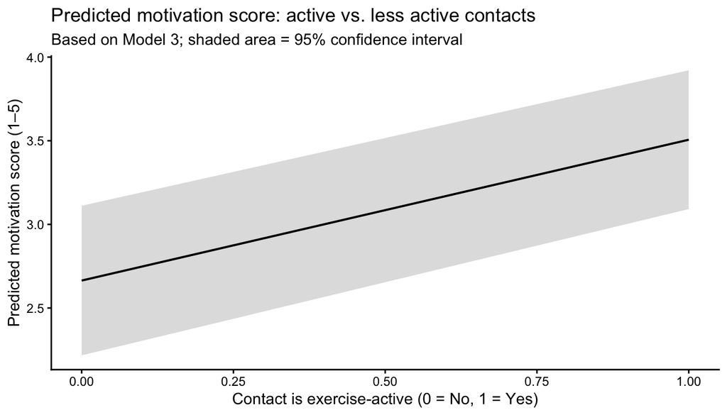

```r
ggpredict(model3, "is_active") |>
  plot() +
  labs(title = "Predicted motivation score: active vs. less active contacts",
       subtitle = "Based on Model 3; shaded area = 95% confidence interval",
       x = "Contact is exercise-active (0 = No, 1 = Yes)",
       y = "Predicted motivation score (1–5)") +
  theme_classic()
```

### 5.2.5 Motivation by Relationship Type

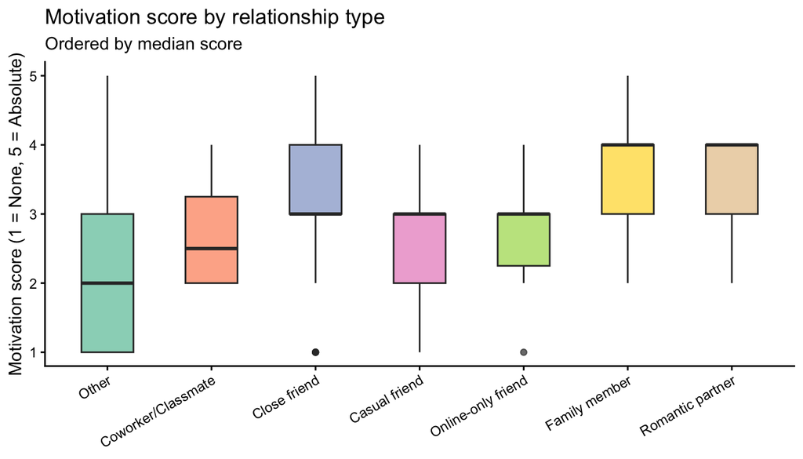

```r
merged_data |>
  filter(!is.na(rel_type), rel_type != "Unknown", !is.na(motivate_score)) |>
  mutate(rel_type = fct_reorder(rel_type, motivate_score, median, .na_rm = TRUE)) |>
  ggplot(aes(x = rel_type, y = motivate_score, fill = rel_type)) +
  geom_boxplot(alpha = 0.7, show.legend = FALSE, width = 0.5) +
  scale_fill_brewer(palette = "Set2") +
  labs(title = "Motivation score by relationship type",
       subtitle = "Ordered by median score",
       x = NULL, y = "Motivation score (1 = None, 5 = Absolute)") +
  theme_classic() +
  theme(axis.text.x = element_text(angle = 30, hjust = 1))
```

### 5.2.6 Interaction Frequency and Motivation

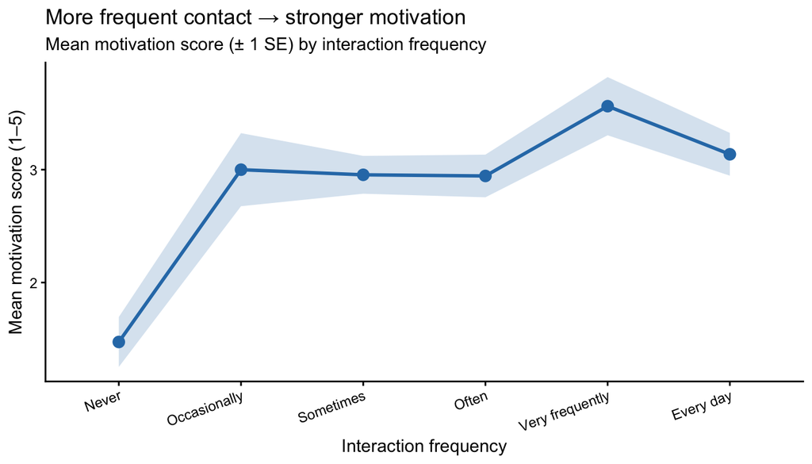

```r
merged_data |>
  filter(!is.na(interact_freq), !is.na(motivate_score)) |>
  mutate(interact_freq = factor(interact_freq, 0:5,
    c("Never", "Occasionally", "Sometimes", "Often", "Very frequently", "Every day"))) |>
  group_by(interact_freq) |>
  summarise(mean_motiv = mean(motivate_score, na.rm = TRUE),
            se = sd(motivate_score, na.rm = TRUE) / sqrt(n()),
            .groups = "drop") |>
  ggplot(aes(x = interact_freq, y = mean_motiv, group = 1)) +
  geom_ribbon(aes(ymin = mean_motiv - se, ymax = mean_motiv + se),
              alpha = 0.2, fill = "#2C7BB6") +
  geom_line(color = "#2C7BB6", linewidth = 1) +
  geom_point(size = 3, color = "#2C7BB6") +
  labs(title = "More frequent contact → stronger motivation",
       subtitle = "Mean motivation score (± 1 SE) by interaction frequency",
       x = "Interaction frequency", y = "Mean motivation score (1–5)") +
  theme_classic() +
  theme(axis.text.x = element_text(angle = 20, hjust = 1))
```

# 6 ERGM — Do Active Alters Cluster Together?

The multilevel models treat each alter independently. An ERGM asks a structurally different question: **does the pattern of ties *among* alters itself carry signal** — specifically, do exercise-active contacts tend to know each other, or do similarly active people cluster together?

We pool all alter-alter edges across ego networks into a single undirected network and fit ERGMs with each alter’s physical activity rating (1–5) as a vertex attribute.

```r
alters_ergm <- alterData |> filter(!is.na(alter_activity))

valid_uuids <- alters_ergm$networkCanvasUUID
edges_ergm  <- edgelistData |>
  filter(networkCanvasSourceUUID %in% valid_uuids,
         networkCanvasTargetUUID  %in% valid_uuids)

v_idx    <- setNames(seq_len(nrow(alters_ergm)), alters_ergm$networkCanvasUUID)
edge_src <- v_idx[edges_ergm$networkCanvasSourceUUID]
edge_tgt <- v_idx[edges_ergm$networkCanvasTargetUUID]
ok       <- !is.na(edge_src) & !is.na(edge_tgt)

net_pool <- network.initialize(nrow(alters_ergm), directed = FALSE)
network::add.edges(net_pool, edge_src[ok], edge_tgt[ok])
network::set.vertex.attribute(net_pool, "alter_activity", alters_ergm$alter_activity)
```

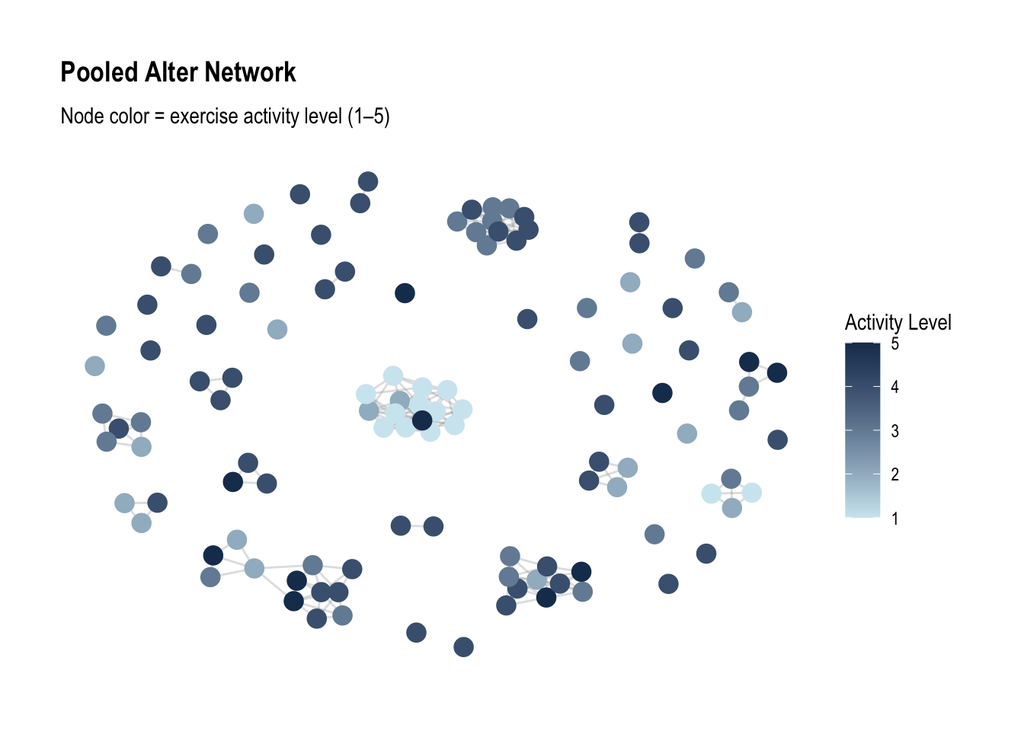

```r
g <- as_tbl_graph(net_pool) |>
  mutate(activity = network::get.vertex.attribute(net_pool, "alter_activity"))

ggraph(g, layout = "fr") +
  geom_edge_link(alpha = 0.3, color = "gray60") +
  geom_node_point(aes(color = activity), size = 4) +
  scale_color_gradient(
    low  = "#d0e8f1",
    high = "#1a3a5c",
    name = "Activity Level"
  ) +
  labs(
    title    = "Pooled Alter Network",
    subtitle = "Node color = exercise activity level (1–5)"
  ) +
  theme_graph() +
  theme(
    plot.title    = element_text(face = "bold", size = 14),
    plot.subtitle = element_text(size = 11)
  )
```

### 6.0.1 Model 1 — Baseline Density

```r
ergm1 <- ergm(net_pool ~ edges)
summary(ergm1)
```

```
Call:
ergm(formula = net_pool ~ edges)

Maximum Likelihood Results:

      Estimate Std. Error MCMC % z value Pr(>|z|)
edges -3.43616    0.07044      0  -48.78   <1e-04 ***
---
Signif. codes:  0 '***' 0.001 '**' 0.01 '*' 0.05 '.' 0.1 ' ' 1

     Null Deviance: 9247  on 6670  degrees of freedom
 Residual Deviance: 1852  on 6669  degrees of freedom

AIC: 1854  BIC: 1861  (Smaller is better. MC Std. Err. = 0)
```

The baseline log-odds of a tie is −3.44, implying a network density of roughly 3%. This is expected: most pairs of contacts across different ego networks share no direct connection.

### 6.0.2 Model 2 — Activity as a Node Covariate

```r
ergm2 <- ergm(net_pool ~ edges + nodecov("alter_activity"))
summary(ergm2)
```

```
Call:
ergm(formula = net_pool ~ edges + nodecov("alter_activity"))

Maximum Likelihood Results:

                       Estimate Std. Error MCMC % z value Pr(>|z|)
edges                  -1.96303    0.24636      0  -7.968   <1e-04 ***
nodecov.alter_activity -0.24313    0.04117      0  -5.906   <1e-04 ***
---
Signif. codes:  0 '***' 0.001 '**' 0.01 '*' 0.05 '.' 0.1 ' ' 1

     Null Deviance: 9247  on 6670  degrees of freedom
 Residual Deviance: 1818  on 6668  degrees of freedom

AIC: 1822  BIC: 1835  (Smaller is better. MC Std. Err. = 0)
```

`nodecov` captures the total activity level of a dyad. Its negative coefficient (β = −0.24, *p* < .001) indicates that, unconditionally, pairs where both alters are highly active are *less* likely to be tied than chance would suggest. AIC drops from 1854 to 1822, confirming improved fit, but the direction hints that high activity alone does not predict connection — something about similarity may matter more.

### 6.0.3 Model 3 — Activity Homophily

```r
ergm3 <- ergm(net_pool ~ edges + nodecov("alter_activity") + absdiff("alter_activity"))
summary(ergm3)
```

```
Call:
ergm(formula = net_pool ~ edges + nodecov("alter_activity") +
    absdiff("alter_activity"))

Maximum Likelihood Results:

                       Estimate Std. Error MCMC % z value Pr(>|z|)
edges                  -1.11071    0.24234      0  -4.583   <1e-04 ***
nodecov.alter_activity -0.27875    0.03710      0  -7.513   <1e-04 ***
absdiff.alter_activity -0.58244    0.08012      0  -7.270   <1e-04 ***
---
Signif. codes:  0 '***' 0.001 '**' 0.01 '*' 0.05 '.' 0.1 ' ' 1

     Null Deviance: 9247  on 6670  degrees of freedom
 Residual Deviance: 1757  on 6667  degrees of freedom

AIC: 1763  BIC: 1783  (Smaller is better. MC Std. Err. = 0)
```

Adding `absdiff` — the absolute difference in activity levels between a pair — substantially improves fit (AIC: 1763). Its negative coefficient (β = −0.58, *p* < .001) confirms **activity homophily**: alters with *similar* activity levels are significantly more likely to know each other. The `nodecov` term remains negative, suggesting that once homophily is accounted for, raw activity level *per se* does not increase connectivity. Together, Model 3 shows that exercise-active contacts tend to cluster with other similarly active people — a structural pattern that may reinforce the motivational effects observed in Part B.

# 7 Lessons from the Pilot

The pilot data collection surfaced several challenges that should inform the design of a larger follow-up study.

**What needs to change.**

*Interface unfamiliarity.* Several participants struggled with the Network Canvas interface, particularly with adding the Name Generator component. This slowed down data collection and may have introduced variability in how carefully participants engaged with the alter-attribute screens. For a next round, a brief hands-on tutorial or a standardized onboarding screen should be added before the interview begins.

*Solo gym-goers.* At least one participant reported going to the gym exclusively alone and had no meaningful contacts to name across the three prompts, yielding a network of size zero. This is a valid but analytically problematic response — it provides no network data to model. Future protocols should include a brief screener: participants who exercise entirely alone could be redirected to a shorter individual-level survey, or the name generators could be broadened to include “people you wish would work out with you” or “people whose exercise habits you admire” to still capture latent network effects.

*Cross-sectional limitation.* A single-wave design cannot distinguish social influence (contacts pushing you to exercise more) from selection (active people choosing to associate with other active people). A longitudinal follow-up — even just two waves, pre- and post-semester — would allow a more credible causal interpretation.

# 8 Conclusions

This study used ego-centric network data to ask whether the people in a graduate student’s exercise-related social network shape how often they go to the gym, and which contacts are most motivating.

At the **aggregate network level**, the answer is largely no. Neither network density, size, proportion of active contacts, nor relationship-type diversity significantly predicted weekly gym attendance. Individual achievement motivation was numerically the strongest predictor, though underpowered to reach significance. This is consistent with H0 and suggests that simply *having* many active people in your life is not enough to change your behavior.

At the **dyadic level**, a clear pattern emerged. Contacts who are themselves highly physically active provide significantly stronger motivation to exercise (β = 0.84, *p* < .001), and this effect is robust to controls for participant characteristics. Interaction frequency matters too, though its effect is smaller. The ERGM results add that similarly active contacts tend to cluster together — forming homophilic micro-groups that may amplify motivational influence through repeated social reinforcement.

The practical implication is specific: exercise support is a relationship-level phenomenon. Interventions that simply expand someone’s network are unlikely to work; what matters is having *particular* close, active contacts who are in regular contact with the target individual. Future research with larger samples, longitudinal design, and objective exercise data (e.g., step counts) would allow a more rigorous test of this conclusion.

# 9 Team Contributions

This project was completed by four team members. Contributions were as follows:

| Member | Role | Specific contributions |
| --- | --- | --- |
| **Jingqi Lu** | Analysis lead & report writing & data collection | Built and debugged the R/Quarto analysis pipeline; wrote OLS, multilevel, and ERGM model code; authored the written report and visualizations; built the Netlify page |
| **Hangyu Lyu** | Protocol design & data collection & writer | Co-designed the Network Canvas interview protocol; recruited participants and conducted interviews; wrote the final page of the protocol and the one-page write-up; authored the conclusion section |
| **Yuxuan Li** | Data collection & cleaning & writer | Wrote the whole research proposal; conducted participant interviews; performed initial data cleaning and variable recoding; authored the OLS model section |
| **Xizhuo Wang** | Protocol design & data collection | Set up the initial Network Canvas framework; conducted participant interviews; authored the introduction and methodology sections |

All four members contributed to the conceptual framing of the research question and participated in team discussions of results.